# Course Project 1

## Tasks

1. Loading and preprocessing the data
2. Explain what is mean total number of steps taken per day
3. Find out What is the average daily activity pattern
4. Imputing missing values
5. Find out the differences in activity patterns between weekdays and weekends

## Loading and preprocessing the data

In the first part, I am going to load the ggplot package and download the data

```r
#Load ggplot package  further use
library(ggplot2)
```

Then extract the data

```r
setwd("C:/Users/PakHang/Desktop/Coursera JHU/Chapter 5/Week 2/data")
activity <- read.csv("activity.csv")
#See the variable types of the data
str(activity)
```

```
## 'data.frame':    17568 obs. of  3 variables:
##  $ steps   : int  NA NA NA NA NA NA NA NA NA NA ...
##  $ date    : Factor w/ 61 levels "2012-10-01","2012-10-02",..: 1 1 1 1 1 1 1 1 1 1 ...
##  $ interval: int  0 5 10 15 20 25 30 35 40 45 ...
```

Find out the missing data and convert the date variable

```r
#Classified the completed and incompleted data
activity$completeness <- complete.cases(activity)
#Subset the complete and missing cases
completedata <- subset(activity, activity$completeness == TRUE)
missingdata <- subset(activity, activity$completeness == FALSE)
#Change date to Date type
completedata$date <- as.POSIXct(completedata$date)
```

## Explain what is mean total number of steps taken per day

Make a histogram of the total number of steps taken each day

```r
#Form the table to prepare for the histogram
stepsperdate<- tapply(completedata$steps, completedata$date, sum)
```

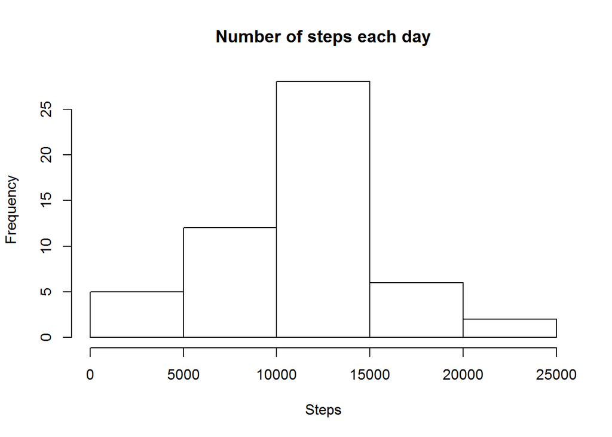

```r
# Plot the Histogram
hist(stepsperdate, xlab = "Steps", main = "Number of steps each day")
```

Compute the mean and median of the total number of steps taken per day

```r
#Compute the mean and the median
mean(stepsperdate, na.rm=TRUE)
```

```
## [1] 10766.19
```

```r
median(stepsperdate, na.rm=TRUE)
```

```
## [1] 10765
```

## Find out What is the average daily activity pattern

Time series plot of the average number of steps taken

```r
# Use aggregate function to summarize data by group
averagesteps <- aggregate(steps ~ interval, completedata, mean)
```

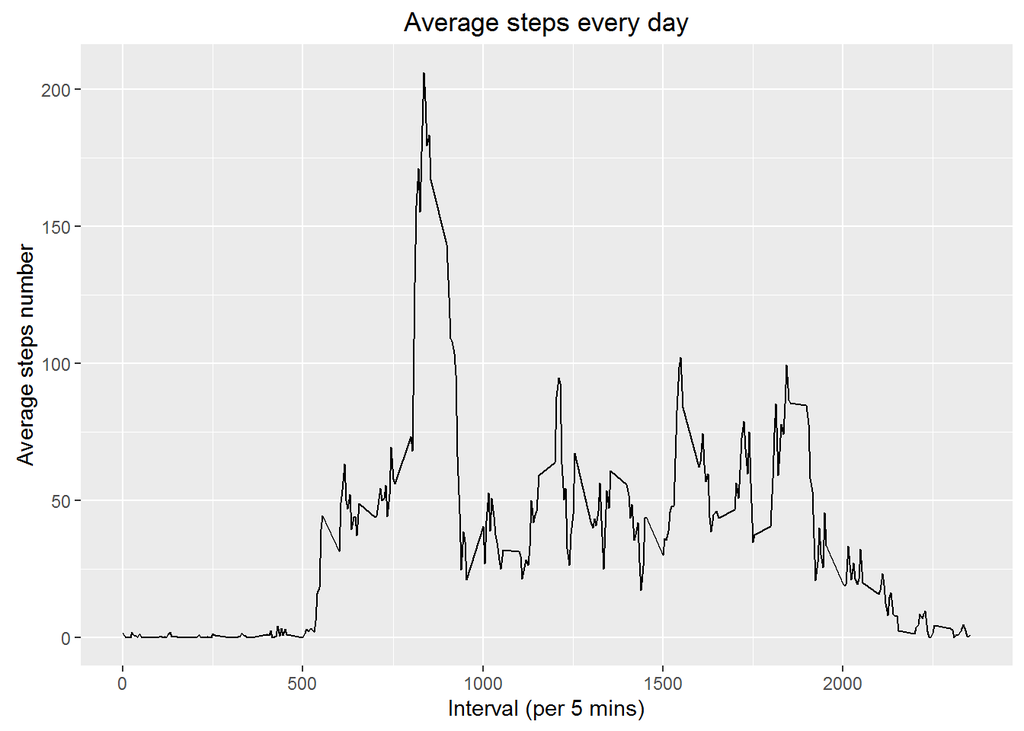

```r
#Plot the graph
qplot(x=interval, y=steps,
data =averagesteps,
geom="line",
xlab = "Interval (per 5 mins)"
,ylab = "Average steps number",
main="Average steps every day")
```

Compute The 5-minute interval that, on average, contains the maximum number of steps

```r
# Compute with which.max function
averagesteps$interval[which.max (averagesteps$steps)]
```

```
## [1] 835
```

That means the highest step counts is in 8:35 am

## Imputing missing values

Calculate and report the total number of missing values in the dataset (i.e. the total number of rows with NAs)

```r
nrow(missingdata)
```

```
## [1] 2304
```

There are 2304 observations that are incompleted

Code to describe and show a strategy for imputing missing data

```r
# Use a for loop to add back all the missing value, by refering to average
for (x in 1:nrow(missingdata)) {
   if (is.na(missingdata$steps[x])) {
      missingvalue <- averagesteps$steps [which (missingdata$interval[x] == averagesteps$interval) ]
      missingdata$steps[x]<- missingvalue
   }
}
#Change the date variable
missingdata$date <- as.POSIXct(missingdata$date)
```

Create a new dataset that is equal to the original dataset but with the missing data filled in

```r
#Combine the dataframes
activitydata <- rbind(completedata, missingdata)
```

Histogram of the total number of steps taken each day after missing values are imputed

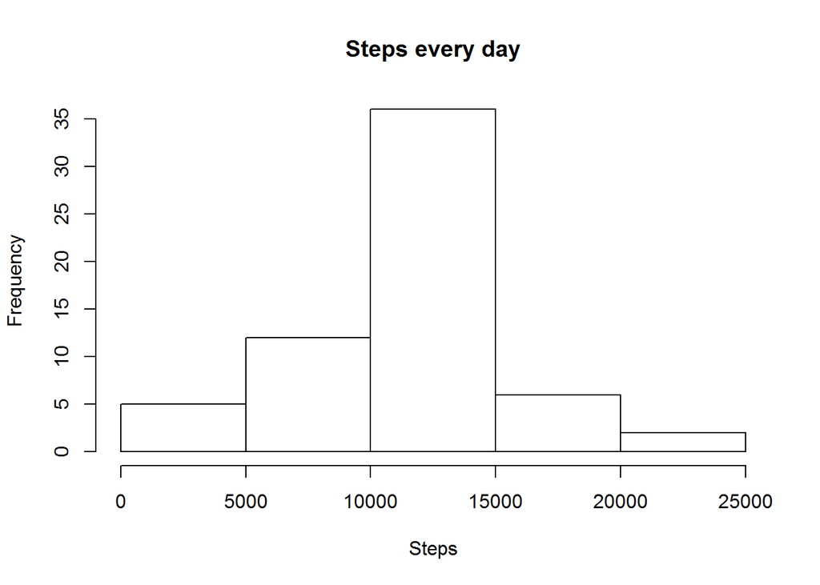

```r
#Form the table before plotting
stepsperdateall<- tapply(activitydata$steps, activitydata$date, sum)
#Plot the graph with ggplot
hist(stepsperdateall, xlab = "Steps", main = "Steps every day")
```

## Find out the differences in activity patterns between weekdays and weekends

Panel plot comparing the average number of steps taken per 5-minute interval across weekdays and weekends

```r
#Make new column weekdays and record the weekday from date variable
Sys.setlocale("LC_TIME", "English")
```

```
## [1] "English_United States.1252"
```

```r
activitydata$day <- weekdays(activitydata$date)

#Add new columns Daytype
activitydata[,"Daytype"] <- NA

#Classify weekday and weekends
activitydata$Daytype = "Weekend"
activitydata$Daytype[!(activitydata$day %in% c("Saturday", "Sunday"))] <- "Weekday"

#Subset the data again by Daytype
weekdaydata <- subset (activitydata, activitydata$Daytype=="Weekday")
weekenddata <- subset (activitydata, activitydata$Daytype=="Weekend")
averagewkdaysteps <- aggregate(steps ~ interval, weekdaydata, mean)
averagewkendsteps <- aggregate(steps ~ interval, weekenddata, mean)
```

Plot the graph

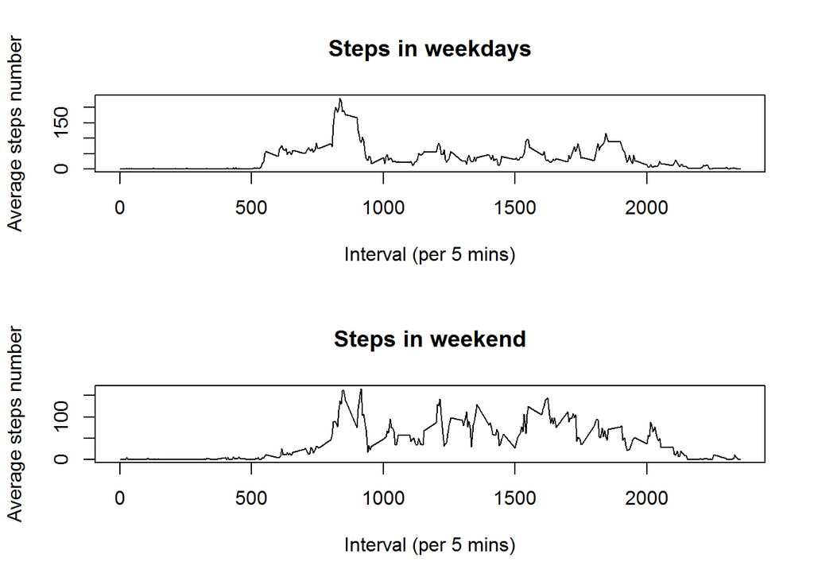

```r
#Set up the parameter
par(mfrow = c(2,1))
#Plot for weekdays
plot(averagewkdaysteps , type = "l", main = "Steps in weekdays", xlab = "Interval (per 5 mins)"
,ylab = "Average steps number")
#Plot for weekends
plot(averagewkendsteps , type = "l", main = "Steps in weekend", xlab = "Interval (per 5 mins)"
,ylab = "Average steps number")
```